# Actividad 3 - Estadística y R para Ciencias de la Salud

Análisis multivariante (PCA), correlaciónes y regresion logística sobre expresión génica relaciónada con la obesidad (dataset ‘Los Simpson’)

Caren Moreno

18/06/2026

# 1 Introducción

El objetivo de esta actividad es explorar, mediante tecnicas de análisis multivariante (PCA), correlación y regresion logística, la relación entre la expresión de 37 genes asociados a obesidad y el indice de masa corporal (IMC) en una población simulada de 59 individuos (dataset *“Los Simpson”*). Se evalua ademas la calidad de los modelos generados y se identifican las variables de ajuste mas relevantes desde un punto de vista epidemiologico.

# 2 Paso 1. Carga y limpieza de los datos

```r
df <- read.csv("Base_de_datos_Los_Simpson_completa.csv",
                row.names = 1, check.names = FALSE, stringsAsFactors = FALSE)

# Identificamos las columnas correspondientes a los 37 genes
genes <- names(df)[which(names(df) == "ADCY3"):which(names(df) == "UHMK1")]

cat("Numero de genes analizados:", length(genes), "\n")
```

```
## Numero de genes analizados: 37
```

```r
cat("Numero de pacientes (filas) antes de la limpieza:", nrow(df), "\n")
```

```
## Numero de pacientes (filas) antes de la limpieza: 59
```

```r
# Comprobación de valores faltantes (NA) en las variables de expresión génica
na_genes <- colSums(is.na(df[, genes]))
cat("Total de NA detectados en variables génicas:", sum(na_genes), "\n")
```

```
## Total de NA detectados en variables génicas: 0
```

```r
filas_incompletas <- which(rowSums(is.na(df[, genes])) > 0)
if (length(filas_incompletas) > 0) {
  df <- df[-filas_incompletas, ]
  cat(length(filas_incompletas), "fila(s) eliminada(s) por datos incompletos.\n")
} else {
  cat("No se detectaron filas incompletas: no fue necesario eliminar pacientes.\n")
}
```

```
## No se detectaron filas incompletas: no fue necesario eliminar pacientes.
```

```r
# Variables derivadas del IMC, necesarias para el resto del trabajo
df <- df %>%
  mutate(
    imc_categoria = case_when(
      imc_kg_m2 < 25 ~ "Normal",
      imc_kg_m2 >= 25 & imc_kg_m2 < 30 ~ "Sobrepeso",
      imc_kg_m2 >= 30 ~ "Obesidad"
    ),
    imc_categoria = factor(imc_categoria, levels = c("Normal", "Sobrepeso", "Obesidad")),
    sobrepeso = factor(ifelse(imc_kg_m2 >= 25, "Si", "No"), levels = c("No", "Si"))
  )

cat("\nDimension final del dataset:", nrow(df), "pacientes x", ncol(df), "variables\n")
```

```
##
## Dimension final del dataset: 59 pacientes x 98 variables
```

```r
knitr::kable(table(df$imc_categoria), col.names = c("Categoría de IMC", "N"),
             caption = "Distribución de pacientes por categoría de IMC") %>%
  kable_styling(full_width = FALSE, bootstrap_options = c("striped", "hover"))
```

Distribución de pacientes por categoría de IMC

| Categoría de IMC | N |
| --- | --- |
| Normal | 32 |
| Sobrepeso | 20 |
| Obesidad | 7 |

# 3 Paso 2. Análisis de normalidad (test de Shapiro-Wilk)

Se evalua la normalidad de la distribución de cada uno de los 37 genes, paso previo indispensable para decidir si los análisis descriptivos e inferenciales posteriores deben abordarse con métodos parametricos o no parametricos.

```r
shapiro_res <- tibble(
  Gen = genes,
  p_valor = sapply(df[, genes], function(x) shapiro.test(x)$p.value)
) %>%
  mutate(
    Distribucion = ifelse(p_valor > 0.05, "Normal", "No normal"),
    p_valor_fmt = ifelse(p_valor < 0.001, formatC(p_valor, format = "e", digits = 2),
                          formatC(p_valor, format = "f", digits = 3))
  ) %>%
  arrange(p_valor)

cat("Genes con distribución NO normal (p<0.05):", sum(shapiro_res$p_valor < 0.05),
    "de", nrow(shapiro_res), "\n")
```

```
## Genes con distribución NO normal (p<0.05): 37 de 37
```

```r
write.csv(shapiro_res, file.path(carpeta_poster, "tabla_shapiro_wilk.csv"), row.names = FALSE)

shapiro_res %>%
  select(Gen, p_valor_fmt, Distribucion) %>%
  knitr::kable(col.names = c("Gen", "Valor p (Shapiro-Wilk)", "Distribución"),
               caption = "Tabla 0. Resultados del test de normalidad de Shapiro-Wilk por gen") %>%
  kable_styling(bootstrap_options = c("striped", "hover"), full_width = FALSE) %>%
  scroll_box(height = "400px")
```

Tabla 0. Resultados del test de normalidad de Shapiro-Wilk por gen

| Gen | Valor p (Shapiro-Wilk) | Distribución |
| --- | --- | --- |
| MRAP2 | 1.04e-11 | No normal |
| BDNF | 2.81e-11 | No normal |
| CADM2 | 8.38e-11 | No normal |
| ANO4 | 8.04e-10 | No normal |
| CREBRF | 8.45e-10 | No normal |
| AGRP | 1.30e-09 | No normal |
| PDE3B | 1.35e-09 | No normal |
| ROBO1 | 1.69e-09 | No normal |
| LEP | 2.11e-09 | No normal |
| SIM1 | 8.91e-09 | No normal |
| NTRK2 | 1.01e-08 | No normal |
| ADCY3 | 1.10e-08 | No normal |
| UBR2 | 1.51e-08 | No normal |
| PPARG | 3.40e-08 | No normal |
| POMC | 3.62e-08 | No normal |
| ANKRD27 | 6.47e-08 | No normal |
| NRP2 | 7.19e-08 | No normal |
| GPR75 | 8.69e-08 | No normal |
| LEPR | 8.93e-08 | No normal |
| PHIP | 1.20e-07 | No normal |
| CNR1 | 2.49e-07 | No normal |
| GIPR | 2.50e-07 | No normal |
| UHMK1 | 2.67e-07 | No normal |
| CALCR | 8.74e-07 | No normal |
| KSR2 | 1.05e-06 | No normal |
| TMEM18 | 1.15e-06 | No normal |
| PCSK1 | 2.32e-06 | No normal |
| NRP1 | 2.59e-06 | No normal |
| CADM1 | 3.14e-06 | No normal |
| SH2B1 | 3.65e-06 | No normal |
| DPP9 | 4.58e-06 | No normal |
| KIAA0586 | 4.65e-06 | No normal |
| FTO | 7.55e-06 | No normal |
| SPARC | 2.67e-05 | No normal |
| MC4R | 4.51e-05 | No normal |
| KIAA1109 | 7.75e-05 | No normal |
| GPR151 | 1.98e-04 | No normal |

**Interpretación:** ninguno de los 37 genes presenta una distribución compatible con la normalidad (p<0.05 en todos los casos), por lo que en los análisis descriptivos se opta por estadísticos de tendencia central robustos (mediana y rango interpercentilico) y por pruebas no parametricas (Kruskal-Wallis) para la comparación entre grupos.

# 4 Paso 3. Análisis de Componentes Principales (PCA)

## 4.1 3.1 Extracción de componentes y varianza explicada

```r
mat_genes <- as.matrix(df[, genes])
pca <- prcomp(mat_genes, center = TRUE, scale. = TRUE)

var_exp <- summary(pca)$importance
tabla_r2 <- tibble(
  Componente = paste0("PC", 1:ncol(var_exp)),
  Valor_propio = round(pca$sdev^2, 3),
  R2_pct = round(var_exp["Proportion of Variance", ] * 100, 2),
  R2_acum_pct = round(var_exp["Cumulative Proportion", ] * 100, 2)
)

write.csv(tabla_r2, file.path(carpeta_poster, "tabla_pca_varianza.csv"), row.names = FALSE)

tabla_r2 %>%
  head(10) %>%
  knitr::kable(col.names = c("Componente", "Valor propio", "R2 (%)", "R2 acumulado (%)"),
               caption = "Tabla 1. Varianza explicada (R2) por cada componente principal") %>%
  kable_styling(bootstrap_options = c("striped", "hover"), full_width = FALSE)
```

Tabla 1. Varianza explicada (R2) por cada componente principal

| Componente | Valor propio | R2 (%) | R2 acumulado (%) |
| --- | --- | --- | --- |
| PC1 | 4.618 | 12.48 | 12.48 |
| PC2 | 3.168 | 8.56 | 21.04 |
| PC3 | 2.415 | 6.53 | 27.57 |
| PC4 | 2.269 | 6.13 | 33.70 |
| PC5 | 1.982 | 5.36 | 39.06 |
| PC6 | 1.809 | 4.89 | 43.94 |
| PC7 | 1.745 | 4.72 | 48.66 |
| PC8 | 1.495 | 4.04 | 52.70 |
| PC9 | 1.467 | 3.96 | 56.67 |
| PC10 | 1.365 | 3.69 | 60.36 |

Las seis primeras componentes acumulan en conjunto un 43.9% de la varianza total de expresión génica, motivo por el cual se conservan para los análisis posteriores.

## 4.2 3.2 Cargas (loadings) de las variables

```r
cargas <- as.data.frame(round(pca$rotation[, 1:6], 3))
cargas$Gen <- rownames(cargas)
cargas <- cargas %>% select(Gen, everything())

write.csv(cargas, file.path(carpeta_poster, "tabla_pca_cargas.csv"), row.names = FALSE)

cargas %>%
  knitr::kable(caption = "Tabla 2. Cargas (loadings) de cada gen en las 6 primeras componentes") %>%
  kable_styling(bootstrap_options = c("striped", "hover")) %>%
  scroll_box(height = "400px")
```

Tabla 2. Cargas (loadings) de cada gen en las 6 primeras componentes

|  | Gen | PC1 | PC2 | PC3 | PC4 | PC5 | PC6 |
| --- | --- | --- | --- | --- | --- | --- | --- |
| ADCY3 | ADCY3 | 0.331 | -0.086 | 0.095 | -0.095 | 0.058 | -0.067 |
| AGRP | AGRP | 0.066 | 0.090 | 0.103 | 0.214 | -0.221 | -0.216 |
| ANKRD27 | ANKRD27 | -0.149 | -0.172 | 0.012 | -0.304 | 0.060 | 0.064 |
| ANO4 | ANO4 | 0.364 | -0.030 | 0.026 | 0.040 | -0.103 | -0.128 |
| BDNF | BDNF | 0.004 | 0.184 | -0.094 | 0.092 | 0.292 | -0.236 |
| CADM1 | CADM1 | -0.085 | -0.083 | -0.061 | 0.219 | -0.224 | 0.293 |
| CADM2 | CADM2 | -0.009 | 0.326 | 0.052 | 0.177 | 0.155 | 0.232 |
| CALCR | CALCR | -0.004 | 0.051 | 0.079 | 0.220 | -0.180 | 0.181 |
| CNR1 | CNR1 | 0.090 | -0.041 | -0.118 | -0.191 | -0.148 | -0.011 |
| CREBRF | CREBRF | 0.005 | -0.104 | 0.329 | 0.068 | 0.149 | 0.114 |
| DPP9 | DPP9 | 0.142 | -0.052 | 0.089 | 0.285 | 0.367 | -0.076 |
| FTO | FTO | -0.086 | -0.249 | 0.303 | -0.047 | 0.202 | -0.103 |
| GIPR | GIPR | 0.083 | 0.068 | 0.134 | 0.077 | 0.363 | 0.384 |
| GPR151 | GPR151 | -0.132 | -0.210 | -0.060 | -0.180 | -0.084 | -0.017 |
| GPR75 | GPR75 | -0.117 | 0.074 | -0.098 | -0.039 | 0.019 | -0.336 |
| KIAA0586 | KIAA0586 | 0.054 | -0.247 | -0.261 | 0.161 | -0.089 | 0.171 |
| KIAA1109 | KIAA1109 | 0.171 | -0.139 | 0.168 | -0.111 | -0.172 | 0.191 |
| KSR2 | KSR2 | -0.066 | 0.260 | 0.191 | -0.134 | -0.191 | 0.186 |
| LEP | LEP | -0.147 | 0.228 | 0.094 | -0.131 | 0.223 | 0.006 |
| LEPR | LEPR | 0.335 | 0.058 | -0.072 | -0.164 | 0.014 | -0.095 |
| MC4R | MC4R | -0.225 | -0.147 | 0.088 | 0.299 | 0.012 | -0.182 |
| MRAP2 | MRAP2 | 0.017 | -0.016 | -0.422 | 0.028 | 0.118 | -0.045 |
| NRP1 | NRP1 | 0.000 | -0.278 | -0.138 | 0.078 | 0.073 | 0.176 |
| NRP2 | NRP2 | -0.087 | -0.050 | 0.116 | 0.140 | -0.208 | -0.272 |
| NTRK2 | NTRK2 | -0.145 | 0.335 | -0.027 | -0.107 | -0.002 | -0.031 |
| PCSK1 | PCSK1 | 0.292 | -0.136 | -0.019 | -0.063 | -0.039 | 0.072 |
| PDE3B | PDE3B | -0.153 | -0.042 | 0.192 | 0.126 | -0.268 | 0.109 |
| PHIP | PHIP | -0.060 | -0.250 | 0.253 | -0.168 | 0.109 | -0.009 |
| POMC | POMC | 0.373 | -0.039 | 0.065 | -0.014 | 0.028 | -0.003 |
| PPARG | PPARG | -0.078 | -0.108 | -0.164 | -0.271 | 0.089 | 0.043 |
| ROBO1 | ROBO1 | -0.054 | 0.166 | 0.130 | -0.418 | -0.067 | 0.124 |
| SH2B1 | SH2B1 | 0.269 | -0.011 | 0.232 | -0.047 | -0.060 | -0.182 |
| SIM1 | SIM1 | -0.151 | -0.186 | 0.139 | -0.058 | 0.250 | -0.116 |
| SPARC | SPARC | 0.066 | -0.019 | -0.244 | -0.029 | 0.137 | 0.204 |
| TMEM18 | TMEM18 | 0.130 | 0.200 | 0.187 | 0.087 | 0.013 | 0.121 |
| UBR2 | UBR2 | -0.119 | -0.101 | 0.149 | -0.071 | -0.097 | -0.054 |
| UHMK1 | UHMK1 | 0.094 | 0.215 | -0.018 | -0.085 | -0.058 | -0.142 |

## 4.3 3.3 Incorporación de los scores de las 6 primeras componentes al dataframe

```r
scores <- as.data.frame(pca$x[, 1:6])
names(scores) <- paste0("PC", 1:6)
df <- bind_cols(df, scores)

cat("Scores PC1-PC6 incorporados. Dimension actual del dataframe:", nrow(df), "x", ncol(df), "\n")
```

```
## Scores PC1-PC6 incorporados. Dimension actual del dataframe: 59 x 104
```

# 5 Paso 4. Visualizaciones del PCA

## 5.1 4.1 Variables coloreadas segun calidad de representación (cos2)

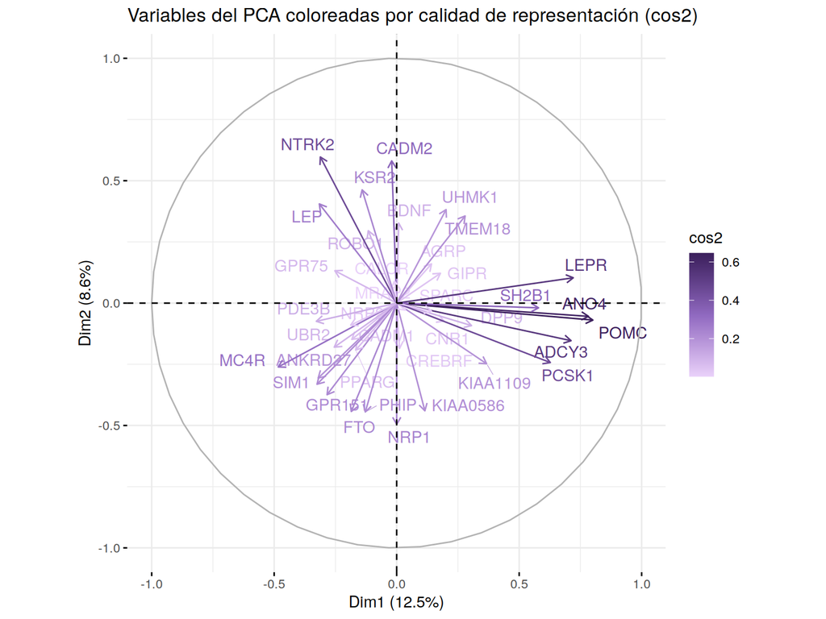

Figura 1. Variables del PCA coloreadas por cos2

```r
p_var_cos2 <- fviz_pca_var(pca,
                            col.var = "cos2",
                            gradient.cols = c("#EAD2FA", "#9069C0", "#3B1F5C"),
                            repel = TRUE,
                            title = "Variables del PCA coloreadas por calidad de representación (cos2)")
ggsave(file.path(carpeta_poster, "fig1_variables_cos2.png"), p_var_cos2,
       width = 7.5, height = 6.5, dpi = 300)
p_var_cos2
```

## 5.2 4.2 Clustering de variables (k=3) sobre el espacio PCA

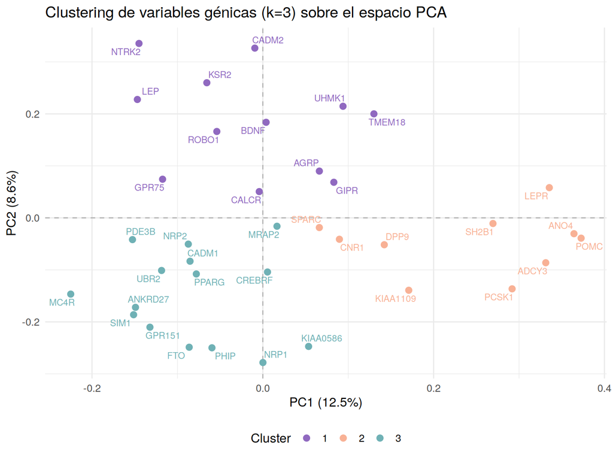

Figura 2. Clustering de variables génicas

```r
var_coords <- as.data.frame(pca$rotation[, 1:2])
km_var <- kmeans(var_coords, centers = 3, nstart = 25)
var_coords$cluster <- factor(km_var$cluster)
var_coords$Gen <- rownames(var_coords)

p_var_cluster <- ggplot(var_coords, aes(PC1, PC2, color = cluster, label = Gen)) +
  geom_hline(yintercept = 0, linetype = "dashed", color = "grey70") +
  geom_vline(xintercept = 0, linetype = "dashed", color = "grey70") +
  geom_point(size = 2.5) +
  geom_text_repel(size = 3, max.overlaps = 20, show.legend = FALSE) +
  scale_color_manual(values = pal_clust, name = "Cluster") +
  labs(title = "Clustering de variables génicas (k=3) sobre el espacio PCA",
       x = paste0("PC1 (", round(var_exp[2,1]*100,1), "%)"),
       y = paste0("PC2 (", round(var_exp[2,2]*100,1), "%)")) +
  theme(legend.position = "bottom")

ggsave(file.path(carpeta_poster, "fig2_cluster_variables.png"), p_var_cluster,
       width = 7.5, height = 6.5, dpi = 300)
write.csv(var_coords %>% select(Gen, PC1, PC2, cluster) %>% arrange(cluster),
          file.path(carpeta_poster, "tabla_cluster_variables.csv"), row.names = FALSE)
p_var_cluster
```

## 5.3 4.3 Contribucion de las variables a PC1 y PC2

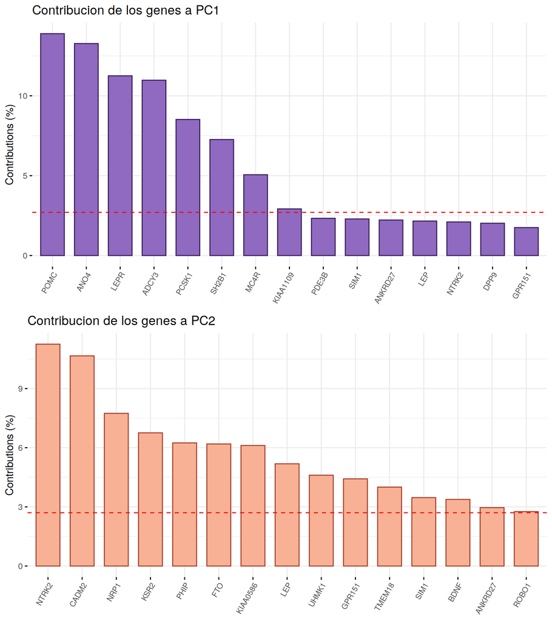

Figura 3. Contribucion de los genes a PC1 y PC2

```r
p_contrib1 <- fviz_contrib(pca, choice = "var", axes = 1, top = 15,
                            fill = "#9069C0", color = "#3B1F5C") +
  labs(title = "Contribucion de los genes a PC1") +
  theme(axis.text.x = element_text(angle = 60, hjust = 1, size = 8))
p_contrib2 <- fviz_contrib(pca, choice = "var", axes = 2, top = 15,
                            fill = "#F8B195", color = "#A8442F") +
  labs(title = "Contribucion de los genes a PC2") +
  theme(axis.text.x = element_text(angle = 60, hjust = 1, size = 8))

p_contrib_combo <- plot_grid(p_contrib1, p_contrib2, ncol = 1)
ggsave(file.path(carpeta_poster, "fig3_contribuciones.png"), p_contrib_combo,
       width = 8, height = 9, dpi = 300)
p_contrib_combo
```

## 5.4 4.4 Distribución de pacientes en PC1-PC2 segun categoría de IMC

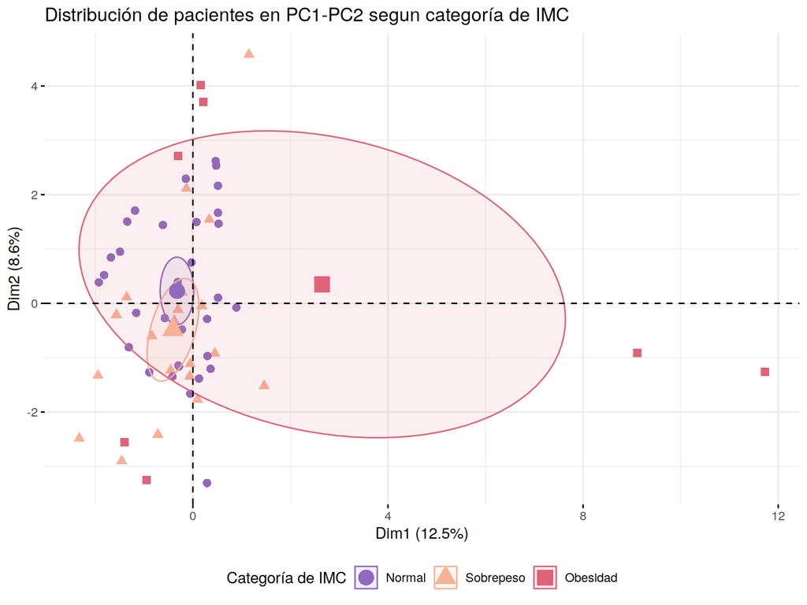

Figura 4. Individuos coloreados por categoría de IMC

```r
p_ind_imc <- fviz_pca_ind(pca,
                           geom.ind = "point",
                           col.ind = df$imc_categoria,
                           palette = pal_imc,
                           addEllipses = TRUE, ellipse.type = "confidence",
                           legend.title = "Categoría de IMC",
                           pointsize = 2.5,
                           title = "Distribución de pacientes en PC1-PC2 segun categoría de IMC") +
  theme(legend.position = "bottom")

ggsave(file.path(carpeta_poster, "fig4_individuos_imc.png"), p_ind_imc,
       width = 7.5, height = 6.5, dpi = 300)
p_ind_imc
```

## 5.5 4.5 Clustering de pacientes (k=3) segun los scores del PCA

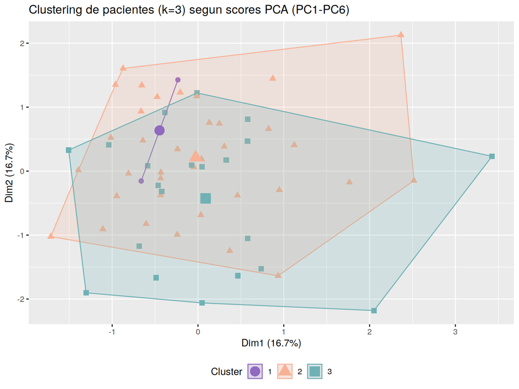

Figura 5. Clustering de pacientes

```r
ind_scores <- df %>% select(PC1, PC2, PC3, PC4, PC5, PC6)
km_ind <- kmeans(ind_scores, centers = 3, nstart = 25)
df$cluster_individuos <- factor(km_ind$cluster)

p_ind_cluster <- fviz_cluster(km_ind, data = ind_scores,
                               geom = "point", ellipse.type = "convex",
                               palette = pal_clust,
                               pointsize = 2.5,
                               legend.title = "Cluster",
                               main = "Clustering de pacientes (k=3) segun scores PCA (PC1-PC6)") +
  theme(legend.position = "bottom")

ggsave(file.path(carpeta_poster, "fig5_cluster_individuos.png"), p_ind_cluster,
       width = 7.5, height = 6.5, dpi = 300)

tab_cross <- table(Cluster = df$cluster_individuos, IMC = df$imc_categoria)
write.csv(as.data.frame(tab_cross), file.path(carpeta_poster, "tabla_cluster_vs_imc.csv"), row.names = FALSE)
p_ind_cluster
```

```r
knitr::kable(tab_cross, caption = "Tabla 3. Cluster de pacientes (PCA) vs. categoría de IMC") %>%
  kable_styling(bootstrap_options = c("striped", "hover"), full_width = FALSE)
```

Tabla 3. Cluster de pacientes (PCA) vs. categoría de IMC

| Normal | Sobrepeso | Obesidad |
| --- | --- | --- |
| 0 | 0 | 2 |
| 18 | 16 | 2 |
| 14 | 4 | 3 |

# 6 Paso 5. Heatmap de correlaciónes de Spearman

## 6.1 5.1 Correlación entre genes y componentes principales

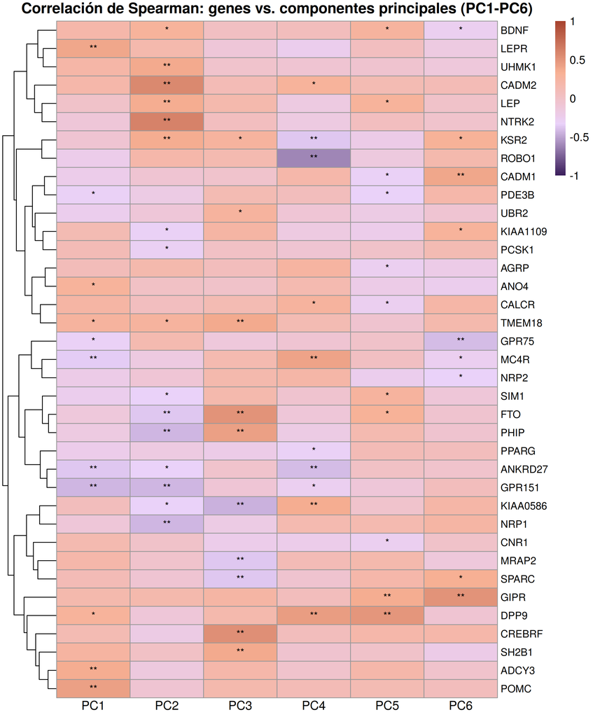

```r
pcs <- paste0("PC", 1:6)
cor_mat <- matrix(NA, nrow = length(genes), ncol = length(pcs), dimnames = list(genes, pcs))
pval_mat <- cor_mat

for (g in genes) {
  for (pc in pcs) {
    test <- suppressWarnings(cor.test(df[[g]], df[[pc]], method = "spearman"))
    cor_mat[g, pc] <- test$estimate
    pval_mat[g, pc] <- test$p.value
  }
}
write.csv(round(cor_mat, 3), file.path(carpeta_poster, "tabla_correlaciones_spearman.csv"))

pheatmap(cor_mat,
         filename = file.path(carpeta_poster, "fig6_heatmap_genes_pc.png"),
         width = 8, height = 9.67,
         color = colorRampPalette(c("#3B1F5C", "#EAD2FA", "#F8B195", "#A8442F"))(100),
         breaks = seq(-1, 1, length.out = 101),
         cluster_cols = FALSE,
         main = "Correlación de Spearman: genes vs. componentes principales (PC1-PC6)",
         display_numbers = matrix(ifelse(pval_mat < 0.05, ifelse(pval_mat < 0.01, "**", "*"), ""),
                                   nrow = nrow(pval_mat)),
         number_color = "black", fontsize = 11, fontsize_row = 10,
         fontsize_number = 10, fontsize_col = 12, angle_col = 0)

knitr::include_graphics(file.path(carpeta_poster, "fig6_heatmap_genes_pc.png"))
```

```r
cat("Correlaciónes significativas (p<0.05):", sum(pval_mat < 0.05), "de", length(pval_mat), "\n")
```

```
## Correlaciónes significativas (p<0.05): 67 de 222
```

**Figura 6.** Heatmap de correlaciónes de Spearman entre la expresión de cada gen y las 6 primeras componentes principales (*p<0.05, **p<0.01).

## 6.2 5.2 Heatmap de expresión génica cruda por paciente

[figure not shown]

```r
mat_genes_scaled <- scale(mat_genes)
rownames(mat_genes_scaled) <- df$nombre
anno_row <- data.frame(IMC = df$imc_categoria); rownames(anno_row) <- df$nombre
anno_colors <- list(IMC = pal_imc)

pheatmap(mat_genes_scaled,
         filename = file.path(carpeta_poster, "fig7_heatmap_genes_pacientes.png"),
         width = 9.33, height = 11.33,
         color = colorRampPalette(c("#3B1F5C", "#EAD2FA", "white", "#F8B195", "#A8442F"))(100),
         annotation_row = anno_row, annotation_colors = anno_colors,
         clustering_distance_rows = "euclidean", clustering_distance_cols = "euclidean",
         clustering_method = "complete",
         main = "Patrones de expresión génica (z-score) por paciente",
         fontsize_row = 6, fontsize_col = 9, fontsize = 10, show_rownames = TRUE)

knitr::include_graphics(file.path(carpeta_poster, "fig7_heatmap_genes_pacientes.png"))
```

**Figura 7.** Patrones de expresión génica (z-score) por paciente, agrupados por clustering jerarquico, con anotacion de categoría de IMC.

# 7 Paso 6. Tabla descriptiva estratificada por terciles del PCA

Se categorizan las 3 primeras componentes en terciles (T1=bajo, T2=medio, T3=alto) y se compara la expresión de cada gen entre los 3 grupos mediante la prueba de Kruskal-Wallis (justificado por la ausencia de normalidad confirmada en el Paso 2).

```r
crear_terciles <- function(x) {
  cortes <- quantile(x, probs = c(1/3, 2/3))
  cut(x, breaks = c(-Inf, cortes[1], cortes[2], Inf), labels = c("T1", "T2", "T3"))
}
df <- df %>% mutate(PC1_t = crear_terciles(PC1), PC2_t = crear_terciles(PC2), PC3_t = crear_terciles(PC3))

mediana_riq <- function(x) {
  med <- median(x); q1 <- quantile(x, 0.25); q3 <- quantile(x, 0.75)
  sprintf("%.2f (%.2f-%.2f)", med, q1, q3)
}

construir_tabla_tercil <- function(data, var_tercil, genes) {
  map_dfr(genes, function(g) {
    valores <- data[[g]]; grupo <- data[[var_tercil]]
    kw <- kruskal.test(valores ~ grupo)
    tibble(Gen = g, T1 = mediana_riq(valores[grupo == "T1"]),
           T2 = mediana_riq(valores[grupo == "T2"]),
           T3 = mediana_riq(valores[grupo == "T3"]), p = kw$p.value)
  })
}

tab_pc1 <- construir_tabla_tercil(df, "PC1_t", genes)
tab_pc2 <- construir_tabla_tercil(df, "PC2_t", genes)
tab_pc3 <- construir_tabla_tercil(df, "PC3_t", genes)

tabla_desc <- tab_pc1 %>%
  left_join(tab_pc2, by = "Gen", suffix = c("_PC1", "_PC2")) %>%
  left_join(tab_pc3 %>% rename_with(~paste0(., "_PC3"), -Gen), by = "Gen") %>%
  mutate(across(starts_with("p_"), ~ifelse(.x < 0.001, "<0.001", sprintf("%.3f", .x))))

write.csv(tabla_desc, file.path(carpeta_poster, "tabla_descriptiva_terciles.csv"), row.names = FALSE)

tabla_desc %>%
  knitr::kable(caption = "Tabla 4. Mediana (RIQ) de expresión génica segun terciles de PC1, PC2 y PC3 (test de Kruskal-Wallis)",
               col.names = c("Gen", "T1", "T2", "T3", "p", "T1", "T2", "T3", "p", "T1", "T2", "T3", "p")) %>%
  add_header_above(c(" " = 1, "Terciles PC1" = 4, "Terciles PC2" = 4, "Terciles PC3" = 4)) %>%
  kable_styling(bootstrap_options = c("striped", "hover"), font_size = 12) %>%
  scroll_box(height = "500px")
```

Tabla 4. Mediana (RIQ) de expresión génica segun terciles de PC1, PC2 y PC3 (test de Kruskal-Wallis)

| Gen | Terciles PC1 T1 | Terciles PC1 T2 | Terciles PC1 T3 | Terciles PC1 p | Terciles PC2 T1 | Terciles PC2 T2 | Terciles PC2 T3 | Terciles PC2 p | Terciles PC3 T1 | Terciles PC3 T2 | Terciles PC3 T3 | Terciles PC3 p |
| --- | --- | --- | --- | --- | --- | --- | --- | --- | --- | --- | --- | --- |
| ADCY3 | -0.76 (-0.84–0.54) | -0.54 (-0.76–0.17) | -0.17 (-0.76–0.17) | 0.016 | -0.18 (-0.76–0.17) | -0.54 (-0.76–0.17) | -0.54 (-0.76–0.17) | 0.490 | -0.54 (-0.84–0.45) | -0.54 (-0.76–0.17) | -0.36 (-0.76–0.17) | 0.351 |
| AGRP | 0.21 (-0.24-0.43) | 0.21 (-0.02-0.25) | 0.22 (-0.24-0.66) | 0.707 | 0.21 (-0.24-0.28) | 0.21 (0.21-0.25) | 0.22 (0.10-0.66) | 0.550 | 0.21 (-0.24-0.41) | 0.25 (0.21-0.51) | 0.21 (-0.24-0.43) | 0.657 |
| ANKRD27 | 0.82 (-0.18-0.82) | -0.18 (-0.35-2.09) | -0.35 (-0.35–0.18) | 0.046 | 0.32 (-0.18-2.09) | 0.82 (-0.35-0.82) | -0.35 (-0.35–0.18) | 0.040 | -0.18 (-0.35-1.14) | -0.18 (-0.35-0.82) | -0.18 (-0.35-2.09) | 0.719 |
| ANO4 | -0.51 (-0.69–0.31) | -0.51 (-0.55–0.31) | -0.31 (-0.55–0.26) | 0.208 | -0.51 (-0.55–0.31) | -0.31 (-0.51–0.13) | -0.51 (-0.55–0.31) | 0.117 | -0.51 (-0.55–0.31) | -0.31 (-0.55–0.24) | -0.51 (-0.55–0.26) | 0.861 |
| BDNF | -0.77 (-0.89–0.65) | -0.84 (-0.89–0.65) | -0.67 (-0.84-1.18) | 0.208 | -0.84 (-0.89–0.68) | -0.70 (-0.86–0.65) | -0.65 (-0.74-1.18) | 0.154 | -0.77 (-0.89–0.18) | -0.70 (-0.84-1.17) | -0.77 (-0.85–0.65) | 0.587 |
| CADM1 | -0.41 (-0.56-1.00) | -0.05 (-0.56-1.00) | -0.56 (-0.74–0.41) | 0.029 | -0.23 (-0.56-1.00) | -0.41 (-0.56-0.47) | -0.41 (-0.56–0.36) | 0.512 | -0.49 (-0.74-1.00) | -0.41 (-0.56-1.00) | -0.41 (-0.56–0.05) | 0.507 |
| CADM2 | -0.67 (-0.72–0.65) | -0.69 (-0.72-1.21) | -0.65 (-0.70-1.21) | 0.367 | -0.71 (-0.82–0.69) | -0.69 (-0.72-0.28) | 1.19 (-0.65-1.21) | <0.001 | -0.65 (-0.72–0.65) | -0.69 (-0.72-1.16) | -0.65 (-0.70-1.21) | 0.399 |
| CALCR | -0.35 (-1.02-1.02) | -0.35 (-0.65-1.02) | -0.21 (-0.35-1.26) | 0.308 | -0.30 (-0.74-1.26) | -0.35 (-0.65-0.34) | 0.43 (-0.59-1.26) | 0.337 | -0.35 (-0.74-1.02) | -0.26 (-0.46-1.50) | -0.26 (-0.65-1.02) | 0.441 |
| CNR1 | -0.24 (-0.30-0.69) | -0.24 (-1.12-0.69) | -0.24 (-0.30-0.69) | 0.667 | -0.24 (-0.30-0.69) | -0.24 (-0.27-0.69) | -0.24 (-0.71-0.69) | 0.996 | 0.69 (-0.26-0.69) | -0.24 (-0.30-0.69) | -0.27 (-1.94-0.69) | 0.151 |
| CREBRF | 0.38 (-1.35-0.65) | 0.62 (-0.88-0.73) | 0.73 (-1.35-0.79) | 0.322 | 0.68 (0.50-0.79) | 0.62 (-1.35-0.73) | 0.10 (-1.35-0.75) | 0.316 | -1.35 (-1.35-0.65) | 0.62 (-1.35-0.73) | 0.73 (0.62-0.79) | 0.001 |
| DPP9 | -1.15 (-1.54–0.24) | 0.75 (-0.26-0.83) | -0.06 (-0.49-0.83) | 0.025 | 0.29 (-0.49-0.83) | -0.26 (-1.15-0.44) | -0.26 (-1.15-0.77) | 0.302 | -0.26 (-1.54-0.77) | -0.26 (-1.15-0.75) | 0.75 (-0.49-0.83) | 0.369 |
| FTO | 0.60 (0.38-0.93) | 0.60 (-0.28-0.93) | 0.60 (-0.36-0.93) | 0.756 | 0.93 (0.60-1.68) | 0.60 (0.16-0.93) | -0.30 (-1.45-0.93) | 0.025 | 0.60 (-0.28-0.60) | 0.60 (-1.06-0.93) | 0.93 (0.84-1.68) | <0.001 |
| GIPR | -0.39 (-0.76-0.04) | 0.04 (-0.18-1.65) | -0.18 (-0.60-0.39) | 0.042 | -0.18 (-0.60-1.47) | -0.18 (-1.02-0.04) | -0.18 (-0.18-0.04) | 0.402 | -0.18 (-0.60-0.04) | -0.18 (-0.62–0.07) | 0.04 (-0.28-1.65) | 0.128 |
| GPR151 | 0.42 (0.05-0.67) | 0.48 (-0.17-0.67) | -0.17 (-1.19-0.18) | 0.008 | 0.57 (0.39-0.85) | -0.17 (-0.68-0.42) | -0.17 (-0.42-0.36) | 0.002 | 0.30 (-0.17-0.67) | 0.12 (-0.68-0.48) | 0.24 (-0.17-0.53) | 0.481 |
| GPR75 | 0.58 (0.32-0.71) | 0.32 (-1.14-0.71) | 0.05 (-1.33-0.46) | 0.090 | 0.32 (-1.33-0.58) | 0.42 (-0.54-0.71) | 0.37 (-0.25-0.71) | 0.513 | 0.50 (-0.25-0.61) | 0.42 (-0.54-0.71) | 0.18 (-1.14-0.61) | 0.498 |
| KIAA0586 | 0.51 (-0.47-0.70) | 0.65 (0.02-0.86) | 0.65 (-0.47-0.86) | 0.822 | 0.75 (0.51-0.86) | 0.65 (0.51-0.75) | -0.47 (-1.26-0.70) | 0.053 | 0.86 (0.62-0.86) | 0.51 (-0.47-0.75) | 0.25 (-0.47-0.65) | 0.019 |
| KIAA1109 | -0.50 (-0.68-0.34) | -0.50 (-0.59-0.30) | -0.50 (-0.68-0.45) | 0.830 | -0.09 (-0.50-0.45) | -0.50 (-0.68-0.30) | -0.59 (-1.58–0.30) | 0.028 | -0.50 (-0.90–0.50) | -0.50 (-0.68-0.37) | -0.10 (-0.68-0.45) | 0.250 |
| KSR2 | -0.23 (-0.47-0.16) | -0.03 (-0.37-0.61) | -0.23 (-0.77-0.16) | 0.570 | -0.37 (-0.77-0.02) | -0.23 (-0.30–0.03) | 0.16 (-0.37-1.99) | 0.041 | -0.30 (-0.77–0.23) | -0.03 (-0.23-0.38) | -0.03 (-0.37-0.61) | 0.027 |
| LEP | 1.02 (-0.37-1.10) | 1.02 (-0.67-1.10) | 1.02 (0.69-1.10) | 0.393 | -0.27 (-0.67-1.04) | 1.02 (-0.59-1.10) | 1.02 (1.02-1.11) | 0.022 | 1.02 (-0.67-1.04) | 1.02 (-0.27-1.10) | 1.02 (-0.37-1.11) | 0.525 |
| LEPR | -0.86 (-0.86–0.20) | -0.20 (-0.86–0.04) | -0.20 (-0.65–0.04) | 0.057 | -0.76 (-0.90–0.17) | -0.20 (-0.86–0.12) | -0.20 (-0.86–0.04) | 0.399 | -0.20 (-0.86–0.04) | -0.65 (-0.86–0.04) | -0.42 (-0.86–0.20) | 0.778 |
| MC4R | 0.52 (-0.02-1.23) | 0.14 (-0.02-0.90) | -0.48 (-0.48-0.33) | 0.039 | 0.90 (-0.13-0.99) | 0.14 (-0.02-1.23) | 0.14 (-0.13-0.90) | 0.771 | -0.02 (-0.48-0.90) | 0.14 (-0.02-1.23) | 0.52 (-0.02-0.98) | 0.443 |
| MRAP2 | -0.24 (-0.53–0.22) | -0.24 (-0.53–0.18) | -0.24 (-0.33–0.12) | 0.246 | -0.24 (-0.53–0.18) | -0.24 (-0.38–0.21) | -0.28 (-0.53–0.18) | 0.884 | -0.18 (-0.31-2.39) | -0.24 (-0.44–0.24) | -0.29 (-0.53–0.18) | 0.070 |
| NRP1 | 0.69 (-0.03-0.78) | -0.01 (-0.01-0.69) | -0.01 (-1.64-0.91) | 0.674 | 0.73 (-0.01-1.29) | 0.69 (-0.01-0.78) | -1.24 (-1.64-0.33) | 0.009 | 0.34 (-0.01-0.78) | 0.21 (-0.86-1.03) | -0.01 (-1.34-0.71) | 0.454 |
| NRP2 | 0.88 (-1.15-0.94) | -0.60 (-1.41-0.94) | -0.88 (-1.15-0.46) | 0.326 | -0.60 (-1.28-0.94) | -0.60 (-1.15-0.88) | -0.09 (-1.28-0.88) | 0.914 | -0.88 (-1.28-0.88) | -0.60 (-1.15-0.88) | 0.75 (-1.15-0.90) | 0.399 |
| NTRK2 | 1.09 (-0.37-1.09) | -0.37 (-0.50-1.21) | 1.09 (-0.63-1.10) | 0.943 | -0.37 (-0.63–0.37) | 1.09 (0.26-1.10) | 1.10 (1.09-1.31) | <0.001 | 1.09 (-0.43-1.10) | 1.09 (0.36-1.09) | -0.37 (-0.63-1.31) | 0.907 |
| PCSK1 | -0.47 (-1.22–0.19) | -0.47 (-0.98–0.17) | -0.47 (-0.75–0.30) | 0.871 | -0.30 (-0.54–0.03) | -0.47 (-0.98–0.30) | -0.61 (-1.22–0.47) | 0.050 | -0.47 (-0.87–0.30) | -0.47 (-0.75–0.27) | -0.47 (-1.22–0.03) | 0.956 |
| PDE3B | 0.91 (0.34-0.93) | 0.34 (0.23-0.91) | 0.23 (-0.20-0.91) | 0.089 | 0.91 (0.23-0.93) | 0.91 (0.23-0.93) | 0.34 (0.23-0.91) | 0.448 | 0.62 (-0.13-0.92) | 0.91 (0.23-0.91) | 0.34 (0.23-0.92) | 0.900 |
| PHIP | 0.12 (-0.88-0.60) | 0.11 (-0.73-0.13) | 0.09 (-0.08-0.11) | 0.518 | 0.13 (0.09-0.60) | 0.09 (-0.39-0.12) | -0.25 (-0.88-0.11) | 0.019 | 0.09 (-0.88-0.11) | 0.09 (-0.88-0.12) | 0.13 (0.10-2.01) | 0.002 |
| POMC | -0.58 (-0.73–0.34) | -0.34 (-0.58–0.24) | -0.24 (-0.58-0.07) | 0.010 | -0.34 (-0.58–0.24) | -0.34 (-0.73-0.07) | -0.34 (-0.58–0.24) | 0.864 | -0.58 (-0.61–0.24) | -0.34 (-0.73–0.09) | -0.29 (-0.58–0.17) | 0.283 |
| PPARG | -0.42 (-0.70-0.80) | -0.42 (-0.69-0.11) | -0.96 (-1.08–0.42) | 0.064 | -0.42 (-0.96-0.18) | -0.42 (-0.69-0.11) | -0.69 (-1.08–0.29) | 0.258 | -0.42 (-0.96-0.23) | -0.42 (-0.96-0.11) | -0.42 (-0.99–0.29) | 0.510 |
| ROBO1 | 0.61 (-0.53-0.66) | 0.61 (0.23-0.77) | 0.23 (-0.94-0.61) | 0.158 | 0.42 (-0.94-0.64) | -0.53 (-2.16-0.76) | 0.61 (0.23-0.62) | 0.401 | 0.42 (-0.94-0.75) | 0.23 (-0.53-0.62) | 0.61 (0.23-0.76) | 0.527 |
| SH2B1 | -0.34 (-1.01–0.12) | -0.21 (-0.93–0.12) | -0.17 (-0.93–0.06) | 0.317 | -0.21 (-0.93–0.12) | -0.21 (-0.93–0.12) | -0.21 (-0.93–0.06) | 0.917 | -1.10 (-1.28–0.21) | -0.12 (-0.21-0.10) | -0.17 (-0.93–0.12) | <0.001 |
| SIM1 | 1.21 (0.73-1.22) | 1.03 (-0.17-1.21) | 0.43 (-0.52-1.21) | 0.144 | 1.21 (0.73-1.21) | 1.03 (-0.17-1.21) | 0.43 (-0.53-1.21) | 0.155 | -0.17 (-0.17-1.21) | 1.03 (-0.52-1.21) | 1.21 (1.03-1.21) | 0.310 |
| SPARC | -0.12 (-0.24–0.04) | -0.04 (-1.25-1.08) | -0.04 (-0.46-0.88) | 0.687 | -0.04 (-0.24-1.08) | -0.04 (-0.12-0.82) | -0.28 (-1.25-0.82) | 0.195 | -0.04 (-0.08-0.88) | -0.04 (-0.19-0.82) | -0.28 (-1.25-0.17) | 0.050 |
| TMEM18 | -0.34 (-0.98–0.00) | 0.72 (-0.34-1.00) | 0.63 (-0.34-0.83) | 0.030 | -0.34 (-0.66-0.88) | -0.24 (-0.66-0.77) | 0.72 (-0.27-0.83) | 0.179 | -0.66 (-0.66-0.65) | 0.63 (-0.66-0.72) | 0.83 (-0.27-1.00) | 0.014 |
| UBR2 | 0.68 (-0.71-1.33) | 0.68 (-0.72-1.41) | -0.71 (-0.74-0.68) | 0.116 | 0.68 (-0.71-1.33) | 0.68 (-0.72-1.01) | -0.71 (-0.74-1.33) | 0.664 | -0.71 (-0.74-0.68) | 0.68 (-0.71-1.33) | 0.68 (-0.71-1.50) | 0.190 |
| UHMK1 | -0.63 (-0.75-0.65) | -0.75 (-1.35–0.63) | 0.67 (-0.63-0.71) | 0.022 | -0.75 (-1.95–0.32) | -0.63 (-0.75-0.71) | 0.66 (-0.63-0.71) | 0.032 | -0.63 (-1.05-0.71) | 0.66 (-0.75-0.71) | -0.69 (-1.05-0.66) | 0.309 |

```r
cat("Genes con diferencia significativa segun tercil de PC1:\n")
```

```
## Genes con diferencia significativa segun tercil de PC1:
```

```r
print(tab_pc1 %>% filter(p < 0.05) %>% arrange(p) %>% pull(Gen))
```

```
##  [1] "GPR151"  "POMC"    "ADCY3"   "UHMK1"   "DPP9"    "CADM1"   "TMEM18"
##  [8] "MC4R"    "GIPR"    "ANKRD27"
```

```r
cat("\nGenes con diferencia significativa segun tercil de PC2:\n")
```

```
##
## Genes con diferencia significativa segun tercil de PC2:
```

```r
print(tab_pc2 %>% filter(p < 0.05) %>% arrange(p) %>% pull(Gen))
```

```
##  [1] "NTRK2"    "CADM2"    "GPR151"   "NRP1"     "PHIP"     "LEP"
##  [7] "FTO"      "KIAA1109" "UHMK1"    "ANKRD27"  "KSR2"
```

```r
cat("\nGenes con diferencia significativa segun tercil de PC3:\n")
```

```
##
## Genes con diferencia significativa segun tercil de PC3:
```

```r
print(tab_pc3 %>% filter(p < 0.05) %>% arrange(p) %>% pull(Gen))
```

```
## [1] "FTO"      "SH2B1"    "CREBRF"   "PHIP"     "TMEM18"   "KIAA0586" "KSR2"
```

# 8 Paso 7. Regresion logística para sobrepeso (IMC >= 25)

## 8.1 7.1 Identificación de variables confusoras

Se realiza un cribado sistemático de variables sociodemográficas y de estilo de vida (excluyendo aquellas que forman parte constitutiva del propio IMC, como peso, talla, perimetros o porcentaje de grasa, para evitar colinealidad estructural con la variable resultado). Se considera variable de ajuste potencial a aquella asociada simultáneamente con el resultado (sobrepeso) y con la exposición principal (terciles de PC1), con un criterio de cribado de p<0.20 (regla habitual para no descartar confusoras moderadas).

```r
candidatas <- c("edad_anios", "sexo", "nivel_educativo", "ingreso_anual_usd",
                "lugar_residencia", "etnicidad", "af_moderada_h_semana",
                "af_intensa_h_semana", "tabaco", "alcohol", "frutas_g_d",
                "verduras_g_d", "carnes_g_d", "bolleria_industrial_g_d")

screening <- map_dfr(candidatas, function(v) {
  x <- df[[v]]
  if (is.numeric(x)) {
    p_outcome  <- tryCatch(wilcox.test(x ~ df$sobrepeso)$p.value, error = function(e) NA)
    p_exposure <- tryCatch(kruskal.test(x ~ df$PC1_t)$p.value, error = function(e) NA)
  } else {
    p_outcome  <- tryCatch(chisq.test(table(x, df$sobrepeso))$p.value, error = function(e) NA)
    p_exposure <- tryCatch(chisq.test(table(x, df$PC1_t))$p.value, error = function(e) NA)
  }
  tibble(Variable = v, p_resultado = round(p_outcome,3), p_exposicion = round(p_exposure,3))
}) %>% mutate(Confusora = ifelse(p_resultado < 0.20 & p_exposicion < 0.20, "Si", "No"))

write.csv(screening, file.path(carpeta_poster, "tabla_screening_confusoras.csv"), row.names = FALSE)

screening %>%
  knitr::kable(caption = "Tabla 5. Cribado de variables confusoras (criterio p<0.20 con resultado y exposición)") %>%
  kable_styling(bootstrap_options = c("striped", "hover"), full_width = FALSE)
```

Tabla 5. Cribado de variables confusoras (criterio p<0.20 con resultado y exposición)

| Variable | p_resultado | p_exposicion | Confusora |
| --- | --- | --- | --- |
| edad_anios | 0.026 | 0.954 | No |
| sexo | 0.361 | 0.176 | No |
| nivel_educativo | 0.566 | 0.468 | No |
| ingreso_anual_usd | 0.917 | 0.754 | No |
| lugar_residencia | 1.000 | 0.343 | No |
| etnicidad | 0.372 | 0.761 | No |
| af_moderada_h_semana | 0.151 | 0.753 | No |
| af_intensa_h_semana | 0.485 | 0.901 | No |
| tabaco | 0.391 | 0.010 | No |
| alcohol | 0.021 | 0.911 | No |
| frutas_g_d | 0.982 | 0.342 | No |
| verduras_g_d | 0.975 | 0.203 | No |
| carnes_g_d | 0.003 | 0.078 | Si |
| bolleria_industrial_g_d | 0.123 | 0.047 | Si |

```r
vars_ajuste <- screening %>% filter(Confusora == "Si") %>% pull(Variable)
if (length(vars_ajuste) == 0) vars_ajuste <- c("edad_anios", "sexo")
cat("\nVariables seleccionadas como ajuste:", paste(vars_ajuste, collapse = ", "), "\n")
```

```
##
## Variables seleccionadas como ajuste: carnes_g_d, bolleria_industrial_g_d
```

## 8.2 7.2 Modelos de regresion logística (niveles de ajuste progresivos)

```r
df_model <- df %>% mutate(sobrepeso_bin = ifelse(sobrepeso == "Si", 1, 0))

f1 <- as.formula("sobrepeso_bin ~ PC1_t + PC2_t + PC3_t")
f2 <- as.formula("sobrepeso_bin ~ PC1_t + PC2_t + PC3_t + edad_anios + sexo")
f3 <- as.formula(paste("sobrepeso_bin ~ PC1_t + PC2_t + PC3_t +",
                        paste(unique(c("edad_anios", "sexo", vars_ajuste)), collapse = " + ")))

m1 <- glm(f1, data = df_model, family = binomial)
m2 <- glm(f2, data = df_model, family = binomial)
m3 <- glm(f3, data = df_model, family = binomial)
```

## 8.3 7.3 Tabla de Odds Ratio (IC95%) y valor p

```r
tidy_modelo <- function(modelo, nombre) {
  tidy(modelo, exponentiate = TRUE, conf.int = TRUE) %>%
    filter(term != "(Intercept)") %>%
    mutate(modelo = nombre,
           `OR (IC95%)` = sprintf("%.2f (%.2f-%.2f)", estimate, conf.low, conf.high),
           p = ifelse(p.value < 0.001, "<0.001", sprintf("%.3f", p.value))) %>%
    select(modelo, term, `OR (IC95%)`, p)
}

tabla_or <- bind_rows(
  tidy_modelo(m1, "Modelo 1 (crudo)"),
  tidy_modelo(m2, "Modelo 2 (+edad+sexo)"),
  tidy_modelo(m3, "Modelo 3 (+confusoras)")
)
write.csv(tabla_or, file.path(carpeta_poster, "tabla_regresion_logistica.csv"), row.names = FALSE)

tabla_or %>%
  pivot_wider(names_from = modelo, values_from = c(`OR (IC95%)`, p)) %>%
  knitr::kable(caption = "Tabla 6. Modelo de regresion logística binaria para sobrepeso, terciles de PCA con 3 niveles de ajuste") %>%
  kable_styling(bootstrap_options = c("striped", "hover"), font_size = 12) %>%
  scroll_box(height = "400px")
```

Tabla 6. Modelo de regresion logística binaria para sobrepeso, terciles de PCA con 3 niveles de ajuste

| term | OR (IC95%)_Modelo 1 (crudo) | OR (IC95%)_Modelo 2 (+edad+sexo) | OR (IC95%)_Modelo 3 (+confusoras) | p_Modelo 1 (crudo) | p_Modelo 2 (+edad+sexo) | p_Modelo 3 (+confusoras) |
| --- | --- | --- | --- | --- | --- | --- |
| PC1_tT2 | 1.19 (0.30-4.78) | 1.29 (0.31-5.60) | 2.79 (0.50-17.98) | 0.800 | 0.725 | 0.252 |
| PC1_tT3 | 1.31 (0.34-5.23) | 1.33 (0.31-5.97) | 0.62 (0.10-3.47) | 0.693 | 0.698 | 0.590 |
| PC2_tT2 | 0.52 (0.13-2.01) | 0.58 (0.13-2.42) | 0.37 (0.07-1.79) | 0.346 | 0.455 | 0.229 |
| PC2_tT3 | 0.24 (0.05-0.92) | 0.26 (0.04-1.41) | 0.20 (0.02-1.38) | 0.044 | 0.132 | 0.120 |
| PC3_tT2 | 2.45 (0.65-9.94) | 2.34 (0.57-10.52) | 2.55 (0.50-14.58) | 0.193 | 0.247 | 0.268 |
| PC3_tT3 | 0.97 (0.24-3.91) | 0.67 (0.14-2.98) | 0.53 (0.09-2.67) | 0.965 | 0.600 | 0.450 |
| edad_anios | NA | 1.04 (1.01-1.08) | 1.04 (1.00-1.08) | NA | 0.032 | 0.088 |
| sexoMasculino | NA | 1.10 (0.18-6.93) | 0.83 (0.10-6.43) | NA | 0.914 | 0.855 |
| carnes_g_d | NA | NA | 1.03 (1.01-1.06) | NA | NA | 0.015 |
| bolleria_industrial_g_d | NA | NA | 0.98 (0.96-1.00) | NA | NA | 0.106 |

## 8.4 7.4 Calidad de los modelos

```r
cat("--- Comparación de AIC ---\n"); print(AIC(m1, m2, m3))
```

```
## --- Comparación de AIC ---
```

```
##    df      AIC
## m1  7 89.20468
## m2  9 87.53463
## m3 11 83.03613
```

```r
cat("\n--- Test de razón de verosimilitud (Modelo 1 vs Modelo 3) ---\n")
```

```
##
## --- Test de razón de verosimilitud (Modelo 1 vs Modelo 3) ---
```

```r
print(lrtest(m1, m3))
```

```
## Likelihood ratio test
##
## Model 1: sobrepeso_bin ~ PC1_t + PC2_t + PC3_t
## Model 2: sobrepeso_bin ~ PC1_t + PC2_t + PC3_t + edad_anios + sexo + carnes_g_d +
##     bolleria_industrial_g_d
##   #Df  LogLik Df  Chisq Pr(>Chisq)
## 1   7 -37.602
## 2  11 -30.518  4 14.169   0.006776 **
## ---
## Signif. codes:  0 '***' 0.001 '**' 0.01 '*' 0.05 '.' 0.1 ' ' 1
```

```r
pseudo_r2 <- function(modelo) 1 - modelo$deviance / modelo$null.deviance
cat("\nPseudo-R2 (McFadden) M1:", round(pseudo_r2(m1),3),
    "| M2:", round(pseudo_r2(m2),3), "| M3:", round(pseudo_r2(m3),3), "\n")
```

```
##
## Pseudo-R2 (McFadden) M1: 0.076 | M2: 0.145 | M3: 0.25
```

```r
cat("\n--- VIF Modelo 3 (multicolinealidad) ---\n")
```

```
##
## --- VIF Modelo 3 (multicolinealidad) ---
```

```r
print(vif(m3))
```

```
##                             GVIF Df GVIF^(1/(2*Df))
## PC1_t                   2.307850  2        1.232542
## PC2_t                   2.041998  2        1.195402
## PC3_t                   1.661697  2        1.135371
## edad_anios              1.444584  1        1.201908
## sexo                    1.728617  1        1.314769
## carnes_g_d              2.125773  1        1.458003
## bolleria_industrial_g_d 2.229591  1        1.493181
```

```r
roc_m1 <- roc(df_model$sobrepeso_bin, predict(m1, type = "response"), quiet = TRUE)
roc_m3 <- roc(df_model$sobrepeso_bin, predict(m3, type = "response"), quiet = TRUE)
cat("\nAUC Modelo 1:", round(auc(roc_m1),3), "| AUC Modelo 3:", round(auc(roc_m3),3), "\n")
```

```
##
## AUC Modelo 1: 0.663 | AUC Modelo 3: 0.818
```

## 8.5 7.5 Forest plot del modelo final ajustado

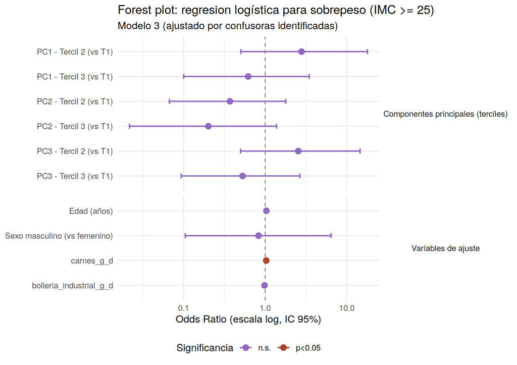

Figura 8. Forest plot del modelo ajustado

```r
tidy_m3 <- tidy(m3, exponentiate = TRUE, conf.int = TRUE) %>%
  filter(term != "(Intercept)") %>%
  mutate(
    term_lab = case_when(
      term == "PC1_tT2" ~ "PC1 - Tercil 2 (vs T1)", term == "PC1_tT3" ~ "PC1 - Tercil 3 (vs T1)",
      term == "PC2_tT2" ~ "PC2 - Tercil 2 (vs T1)", term == "PC2_tT3" ~ "PC2 - Tercil 3 (vs T1)",
      term == "PC3_tT2" ~ "PC3 - Tercil 2 (vs T1)", term == "PC3_tT3" ~ "PC3 - Tercil 3 (vs T1)",
      term == "edad_anios" ~ "Edad (años)", term == "sexoMasculino" ~ "Sexo masculino (vs femenino)",
      TRUE ~ term),
    grupo = ifelse(str_starts(term, "PC"), "Componentes principales (terciles)", "Variables de ajuste"),
    sig = ifelse(p.value < 0.05, "p<0.05", "n.s."))
tidy_m3$term_lab <- factor(tidy_m3$term_lab, levels = rev(tidy_m3$term_lab))

p_forest <- ggplot(tidy_m3, aes(x = estimate, y = term_lab, color = sig)) +
  geom_vline(xintercept = 1, linetype = "dashed", color = "grey50") +
  geom_errorbarh(aes(xmin = conf.low, xmax = conf.high), height = 0.2, linewidth = 0.8) +
  geom_point(size = 3) +
  scale_color_manual(values = c("p<0.05" = "#A8442F", "n.s." = "#9069C0")) +
  scale_x_log10() +
  facet_grid(grupo ~ ., scales = "free_y", space = "free_y") +
  labs(title = "Forest plot: regresion logística para sobrepeso (IMC >= 25)",
       subtitle = "Modelo 3 (ajustado por confusoras identificadas)",
       x = "Odds Ratio (escala log, IC 95%)", y = NULL, color = "Significancia") +
  theme(legend.position = "bottom", strip.text.y = element_text(angle = 0))

ggsave(file.path(carpeta_poster, "fig8_forest_plot.png"), p_forest, width = 8.5, height = 6, dpi = 300)
p_forest
```

## 8.6 7.6 Comparación gráfica de los 3 modelos

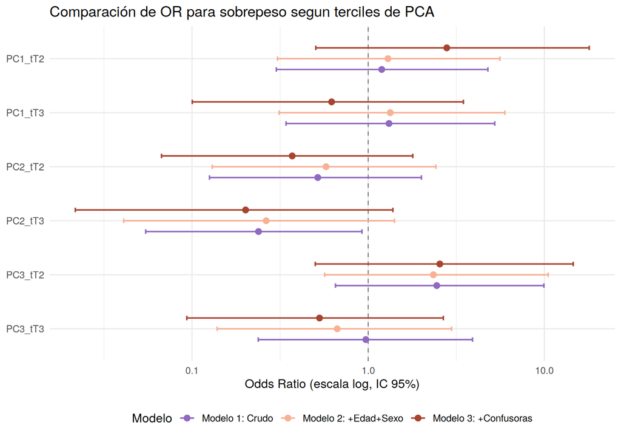

Figura 9. Comparación de OR entre modelos

```r
tidy_simple <- function(modelo, nombre) {
  tidy(modelo, exponentiate = TRUE, conf.int = TRUE) %>%
    filter(str_starts(term, "PC")) %>% mutate(modelo = nombre)
}
comp <- bind_rows(tidy_simple(m1, "Modelo 1: Crudo"),
                   tidy_simple(m2, "Modelo 2: +Edad+Sexo"),
                   tidy_simple(m3, "Modelo 3: +Confusoras"))
comp$term <- factor(comp$term, levels = rev(unique(comp$term)))

p_comp <- ggplot(comp, aes(x = estimate, y = term, color = modelo)) +
  geom_vline(xintercept = 1, linetype = "dashed", color = "grey50") +
  geom_errorbarh(aes(xmin = conf.low, xmax = conf.high), height = 0.25,
                  position = position_dodge(width = 0.6), linewidth = 0.7) +
  geom_point(size = 2.5, position = position_dodge(width = 0.6)) +
  scale_color_manual(values = c("Modelo 1: Crudo" = "#9069C0", "Modelo 2: +Edad+Sexo" = "#F8B195",
                                 "Modelo 3: +Confusoras" = "#A8442F")) +
  scale_x_log10() +
  labs(title = "Comparación de OR para sobrepeso segun terciles de PCA",
       x = "Odds Ratio (escala log, IC 95%)", y = NULL, color = "Modelo") +
  theme(legend.position = "bottom")

ggsave(file.path(carpeta_poster, "fig9_comparacion_modelos.png"), p_comp, width = 8.5, height = 6, dpi = 300)
p_comp
```

# 9 Conclusiones

```r
cat("Archivos guardados en la carpeta '", carpeta_poster, "':\n", sep = "")
```

```
## Archivos guardados en la carpeta 'figuras_poster':
```

```r
print(list.files(carpeta_poster))
```

```
##  [1] "fig1_variables_cos2.png"          "fig2_cluster_variables.png"
##  [3] "fig3_contribuciones.png"          "fig4_individuos_imc.png"
##  [5] "fig5_cluster_individuos.png"      "fig6_heatmap_genes_pc.png"
##  [7] "fig7_heatmap_genes_pacientes.png" "fig8_forest_plot.png"
##  [9] "fig9_comparacion_modelos.png"     "tabla_cluster_variables.csv"
## [11] "tabla_cluster_vs_imc.csv"         "tabla_correlaciones_spearman.csv"
## [13] "tabla_descriptiva_terciles.csv"   "tabla_pca_cargas.csv"
## [15] "tabla_pca_varianza.csv"           "tabla_regresion_logistica.csv"
## [17] "tabla_screening_confusoras.csv"   "tabla_shapiro_wilk.csv"
```